# Презентация лабораторной работы

Лабораторная работа №3

Швецов Михаил Романович

1132236100@rudn.ru

Российский университет дружбы народов

2026-09-02

# Информация

## Докладчик

- **Швецов Михаил Романович**
- студент кафедры теории вероятностей и кибербезопасности
- Российский университет дружбы народов им. П. Лумумбы
- 1132236100@rudn.ru
- https://DarkkLord.github.io/ru/

[figure not shown]

# Выполнение лабораторной работы

Создаём каталог лабораторной работы. (рис. 1).

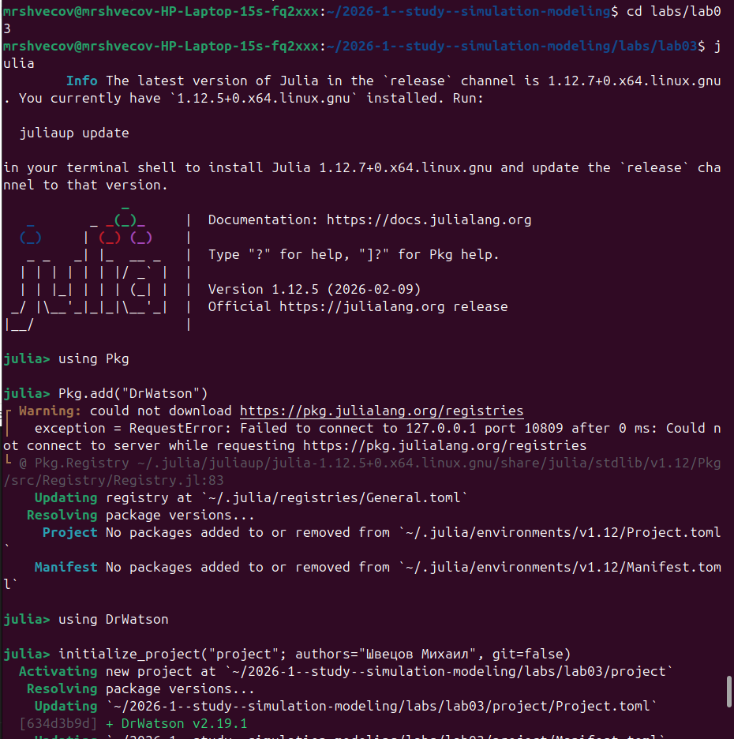

Рисунок 1: Создание каталога:

Далее в каталоге src создаём необходимый скрипт (рис. 2).

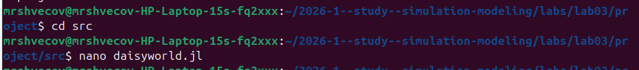

Рисунок 2: Создание скрипта в необходимом каталоге:

Устанавливаем все необходимые пакеты (рис. 3) (рис. 4).

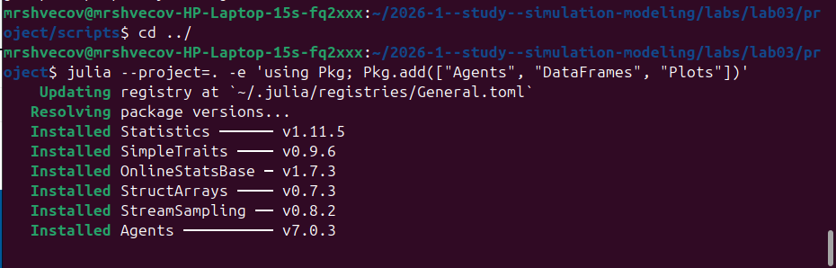

Рисунок 3: Установка:

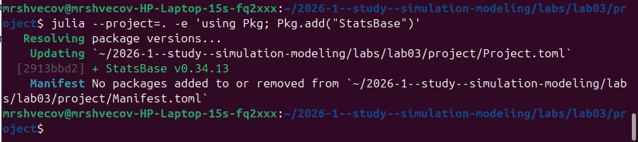

Рисунок 4: Установка:

Создаём и выполняем scripts/daisyworld.jl (рис. 5).

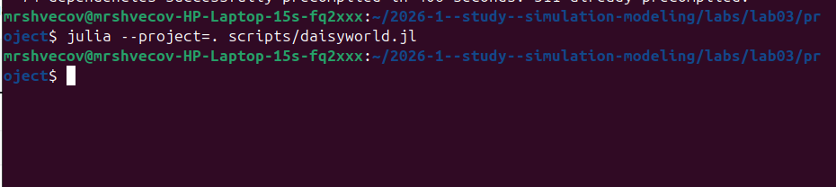

Рисунок 5: Выполнение:

Создаём литературный стиль (чистый код, markdown, notebook) (рис. 6) (рис. 7) (рис. 8).

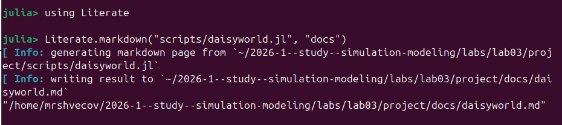

Рисунок 6: Markdown:

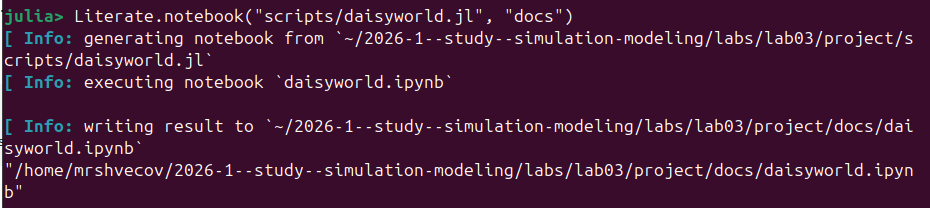

Рисунок 7: Notebook:

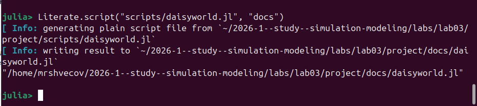

Рисунок 8: Script:

Создадим скрипт scripts/daisyworld-animate.jl и загрузим его на фидеохостинг [RUTUBE](https://rutube.ru/video/3d087a9269bfeaabf7ed149ba37f9c76/) (рис. 9).

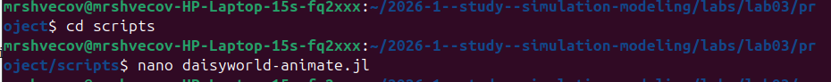

Рисунок 9: Создание скрипта

Создадим скрипт scripts/daisyworld-count.jl (рис. 10).

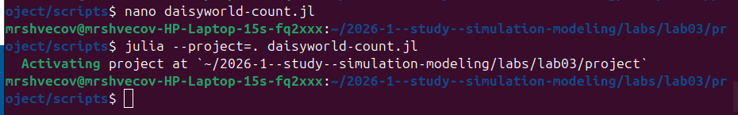

Рисунок 10: Создание и выполнение:

Создание литературного стиля (рис. 11).

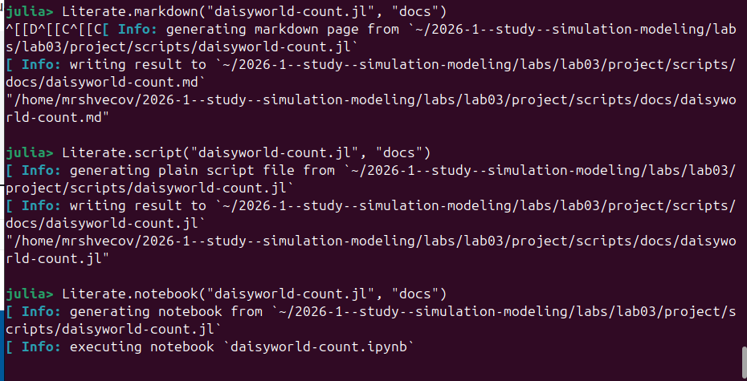

Рисунок 11: Литературный стиль:

Создание файла scripts/daisyworld-luminosity.jl, создание для него литературного стиля (рис. 12).

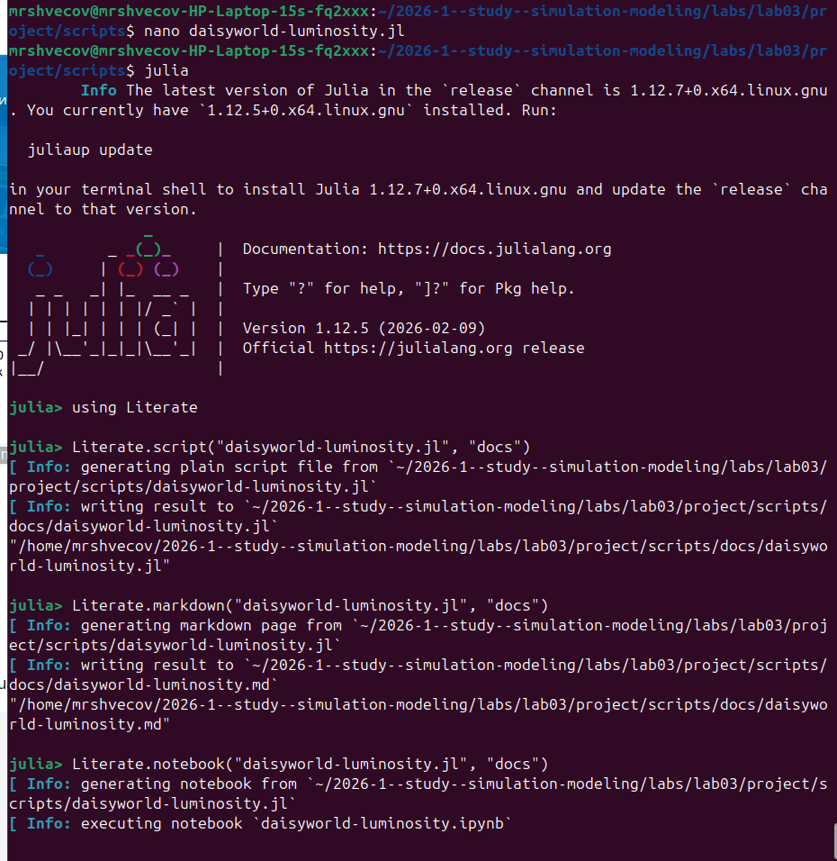

Рисунок 12: Создание файла и литературного стиля для него:

Выполнение скрипта scripts/daisyworld-luminosity.jl (рис. 13).

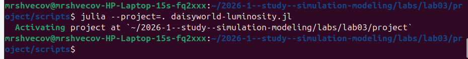

Рисунок 13: Выполнение скрипта:

Создание и выполение scripts/daisyworld__param.jl (рис. 14).

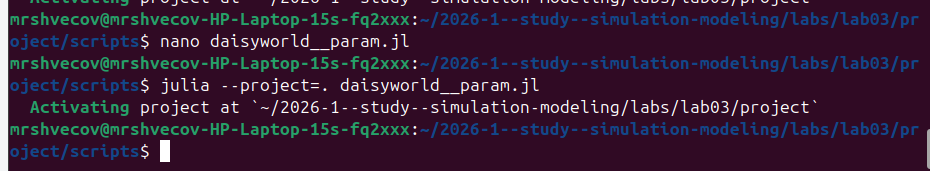

Рисунок 14: Создание и выполение scripts/daisyworld__param.jl:

Создание литературного стиля scripts/daisyworld__param.jl (рис. 15).

[figure not shown]

Рисунок 15: Созданеи литературного стиля:

Создание и выполение scripts/daisyworld-count__param.jl (рис. 16).

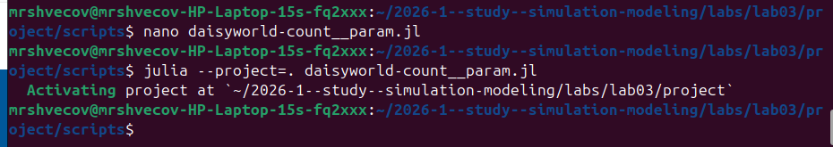

Рисунок 16: Создание и выполение scripts/daisyworld-count__param.jl:

Создание литературного стиля scripts/daisyworld-count__param.jl (рис. 17).

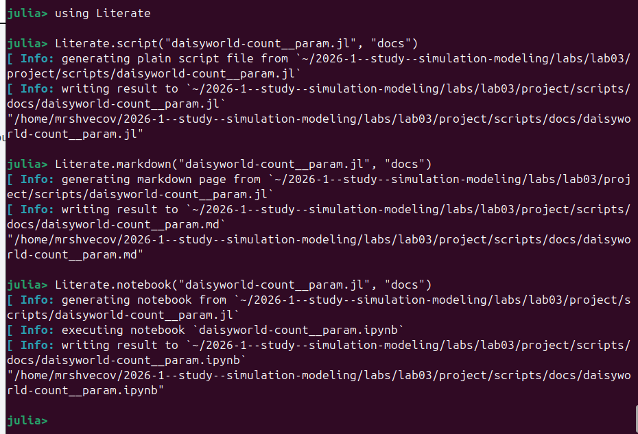

Рисунок 17: Создание литературного стиля scripts/daisyworld-count__param.jl:

Создание и выполение scripts/daisyworld-luminosity__param.jl (рис. 18).

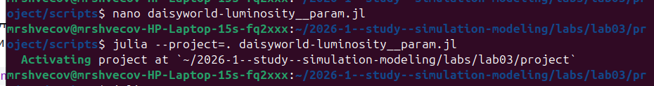

Рисунок 18: Выполнение и создание :

Создание литературного стиля scripts/daisyworld-luminosity__param.jl (рис. 19).

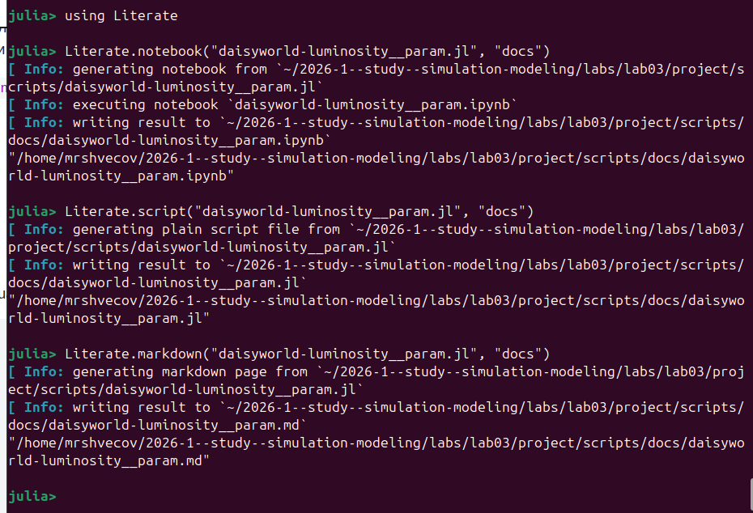

Рисунок 19: Создание литературного стиля scripts/daisyworld-luminosity__param.jl:

# Выводы

В данной лабораторной работе мы попрактиковались в создании литературного стиля кода на примере Модели Daisyworld.